# Practical Machine Learning Project

Nitzan Sherman

Tuesday, August 18, 2015

# Project Purpose

The purpose of this project is to create a model that classifies weight lifting form given a set of variables. The data collected is from various sensors for various subjects. Please see http://groupware.les.inf.puc-rio.br/har for more information the source data.

# Necessary Packages

```r
library(caret)
```

# Preprocessing

Before building the model, I wanted to ensure I understood the underlying data.

```r
data <- read.csv("pm1-training.csv",na.strings = c("NA","","#DIV/0!"))
summary(data)
```

```
##        X            user_name    raw_timestamp_part_1 raw_timestamp_part_2
##  Min.   :    1   adelmo  :3892   Min.   :1.322e+09    Min.   :   294
##  1st Qu.: 4906   carlitos:3112   1st Qu.:1.323e+09    1st Qu.:252912
##  Median : 9812   charles :3536   Median :1.323e+09    Median :496380
##  Mean   : 9812   eurico  :3070   Mean   :1.323e+09    Mean   :500656
##  3rd Qu.:14717   jeremy  :3402   3rd Qu.:1.323e+09    3rd Qu.:751891
##  Max.   :19622   pedro   :2610   Max.   :1.323e+09    Max.   :998801
##
##           cvtd_timestamp  new_window    num_window      roll_belt
##  28/11/2011 14:14: 1498   no :19216   Min.   :  1.0   Min.   :-28.90
##  05/12/2011 11:24: 1497   yes:  406   1st Qu.:222.0   1st Qu.:  1.10
##  30/11/2011 17:11: 1440               Median :424.0   Median :113.00
##  05/12/2011 11:25: 1425               Mean   :430.6   Mean   : 64.41
##  02/12/2011 14:57: 1380               3rd Qu.:644.0   3rd Qu.:123.00
##  02/12/2011 13:34: 1375               Max.   :864.0   Max.   :162.00
##  (Other)         :11007
##    pitch_belt          yaw_belt       total_accel_belt kurtosis_roll_belt
##  Min.   :-55.8000   Min.   :-180.00   Min.   : 0.00    Min.   :-2.121
##  1st Qu.:  1.7600   1st Qu.: -88.30   1st Qu.: 3.00    1st Qu.:-1.329
##  Median :  5.2800   Median : -13.00   Median :17.00    Median :-0.899
##  Mean   :  0.3053   Mean   : -11.21   Mean   :11.31    Mean   :-0.220
##  3rd Qu.: 14.9000   3rd Qu.:  12.90   3rd Qu.:18.00    3rd Qu.:-0.219
##  Max.   : 60.3000   Max.   : 179.00   Max.   :29.00    Max.   :33.000
##                                                        NA's   :19226
##  kurtosis_picth_belt kurtosis_yaw_belt skewness_roll_belt
##  Min.   :-2.190      Mode:logical      Min.   :-5.745
##  1st Qu.:-1.107      NA's:19622        1st Qu.:-0.444
##  Median :-0.151                        Median : 0.000
##  Mean   : 4.334                        Mean   :-0.026
##  3rd Qu.: 3.178                        3rd Qu.: 0.417
##  Max.   :58.000                        Max.   : 3.595
##  NA's   :19248                         NA's   :19225
##  skewness_roll_belt.1 skewness_yaw_belt max_roll_belt     max_picth_belt
##  Min.   :-7.616       Mode:logical      Min.   :-94.300   Min.   : 3.00
##  1st Qu.:-1.114       NA's:19622        1st Qu.:-88.000   1st Qu.: 5.00
##  Median :-0.068                         Median : -5.100   Median :18.00
##  Mean   :-0.296                         Mean   : -6.667   Mean   :12.92
##  3rd Qu.: 0.661                         3rd Qu.: 18.500   3rd Qu.:19.00
##  Max.   : 7.348                         Max.   :180.000   Max.   :30.00
##  NA's   :19248                          NA's   :19216     NA's   :19216
```

[output cut: 313 more lines]

```
##  Min.   :-446.00   Min.   :-1280.0   Min.   :-896.0   Min.   :-973.0
##  1st Qu.:-182.00   1st Qu.: -616.0   1st Qu.:   2.0   1st Qu.: 191.0
##  Median : -39.00   Median : -378.0   Median : 591.0   Median : 511.0
##  Mean   : -55.29   Mean   : -312.6   Mean   : 380.1   Mean   : 393.6
##  3rd Qu.:  26.00   3rd Qu.:  -73.0   3rd Qu.: 737.0   3rd Qu.: 653.0
##  Max.   : 291.00   Max.   :  672.0   Max.   :1480.0   Max.   :1090.0
##
##  classe
##  A:5580
##  B:3797
##  C:3422
##  D:3216
##  E:3607
##
##
```

After looking at the summary of all 160 variables I decided to do the following:

1. Remove all bookkeeping columns(first 7 columns)
2. Remove all columns that have more than or equal to 90% NAs.

Some models such as random forest and gradient boosting can handle NAs fine, but I wanted to minimize noise and felt these variables would not be useful for prediction.

```r
clean_data <- data[,colSums(is.na(data)) <= .1 * nrow(data)]
clean_data <- clean_data[,c(8:ncol(clean_data))]
```

# Model Choice and Testing/Training Breakup

I decided to use a gradient boosting model. I wanted a tree based model that would be relatively easy to interpet and had strong accuracy as well. The one issue with gbm is the fact that the algorithm is prone to overfitting. In order to reduce this, I have also decided to do repeated cross validation with 5 folds and two repeats. Other methods of preventing overfitting including pruning trees and modifying other parameters.

Even though I’m using repeated cross validation, I’ve set aside 40% of data for my validation set. This will help me see how accurate my model will do out of sample and confirm my predictions for error. It also gives me leeway to train other models with my 60% of training data, if I decided to train other models.

```r
set.seed(13)
fitControl <- trainControl(method = "repeatedcv",number = 5,repeats = 2)
trainingIndexes <- createDataPartition(y = clean_data$classe,p=.6,list = FALSE)
training_data <- clean_data[trainingIndexes,]
validation_data <- clean_data[-trainingIndexes,]
gbmFit <- train(classe ~.,data = training_data,method = "gbm",trControl = fitControl,verbose = FALSE)
```

# Model Fit, Analysis and Error Fit

```r
gbmFit
```

```
## Stochastic Gradient Boosting
##
## 11776 samples
##    52 predictor
##     5 classes: 'A', 'B', 'C', 'D', 'E'
##
## No pre-processing
## Resampling: Cross-Validated (5 fold, repeated 2 times)
## Summary of sample sizes: 9423, 9420, 9420, 9420, 9421, 9420, ...
## Resampling results across tuning parameters:
##
##   interaction.depth  n.trees  Accuracy   Kappa      Accuracy SD
##   1                   50      0.7537825  0.6878528  0.014146749
##   1                  100      0.8211630  0.7736651  0.005518794
##   1                  150      0.8540268  0.8153000  0.007958974
##   2                   50      0.8547480  0.8160415  0.008845585
##   2                  100      0.9058694  0.8808619  0.006884275
##   2                  150      0.9296041  0.9109236  0.005401155
##   3                   50      0.8955085  0.8677240  0.004329032
##   3                  100      0.9397514  0.9237509  0.005855188
##   3                  150      0.9595368  0.9488010  0.005313518
##   Kappa SD
##   0.017861539
##   0.006919168
##   0.010028457
##   0.011178025
##   0.008699454
##   0.006844608
##   0.005475511
##   0.007415085
##   0.006732840
##
## Tuning parameter 'shrinkage' was held constant at a value of 0.1
##
## Tuning parameter 'n.minobsinnode' was held constant at a value of 10
## Accuracy was used to select the optimal model using  the largest value.
## The final values used for the model were n.trees = 150,
##  interaction.depth = 3, shrinkage = 0.1 and n.minobsinnode = 10.
```

I also wanted to see how many variables were actually important to the analysis.

```r
gbmFit$finalModel
```

```
## A gradient boosted model with multinomial loss function.
## 150 iterations were performed.
## There were 52 predictors of which 44 had non-zero influence.
```

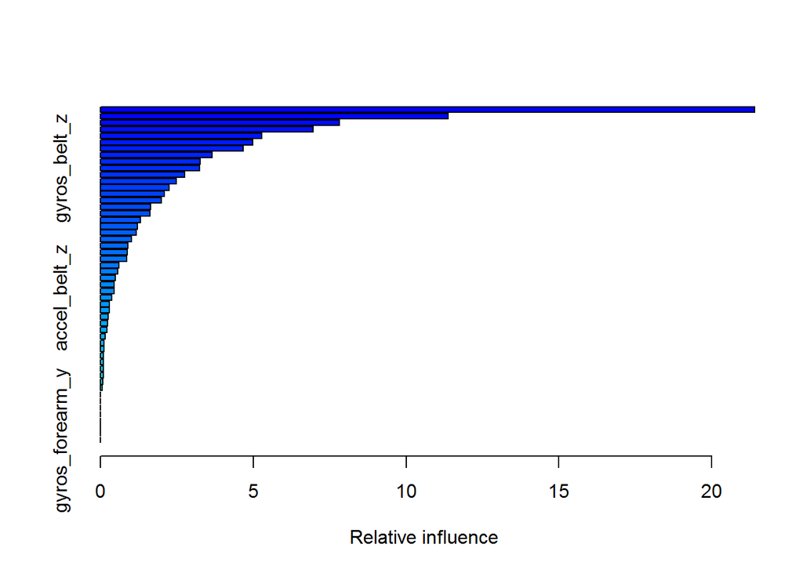

```
##                                       var     rel.inf
## roll_belt                       roll_belt 21.39827780
## pitch_forearm               pitch_forearm 11.37399568
## yaw_belt                         yaw_belt  7.82635117
## magnet_dumbbell_z       magnet_dumbbell_z  6.95343712
## magnet_dumbbell_y       magnet_dumbbell_y  5.27678896
## roll_forearm                 roll_forearm  4.99498948
## magnet_belt_z               magnet_belt_z  4.66624642
## roll_dumbbell               roll_dumbbell  3.65359617
## pitch_belt                     pitch_belt  3.26110530
## gyros_belt_z                 gyros_belt_z  3.23965518
## accel_forearm_x           accel_forearm_x  2.75280760
## accel_forearm_z           accel_forearm_z  2.48100389
## gyros_dumbbell_y         gyros_dumbbell_y  2.24106545
## magnet_forearm_z         magnet_forearm_z  2.09295561
## accel_dumbbell_y         accel_dumbbell_y  2.00310382
## accel_dumbbell_x         accel_dumbbell_x  1.63437117
## magnet_arm_z                 magnet_arm_z  1.62095285
## magnet_belt_y               magnet_belt_y  1.30463426
## magnet_dumbbell_x       magnet_dumbbell_x  1.21294181
## yaw_arm                           yaw_arm  1.17517902
## roll_arm                         roll_arm  1.01775772
## magnet_belt_x               magnet_belt_x  0.89925317
## magnet_arm_y                 magnet_arm_y  0.87977338
## magnet_arm_x                 magnet_arm_x  0.85686605
## magnet_forearm_x         magnet_forearm_x  0.60365239
## accel_dumbbell_z         accel_dumbbell_z  0.57354541
## gyros_arm_y                   gyros_arm_y  0.48352984
## gyros_belt_y                 gyros_belt_y  0.45625818
## total_accel_dumbbell total_accel_dumbbell  0.45483880
## accel_belt_z                 accel_belt_z  0.38246539
## gyros_dumbbell_x         gyros_dumbbell_x  0.28605462
## pitch_dumbbell             pitch_dumbbell  0.28587926
## accel_arm_x                   accel_arm_x  0.26204270
## total_accel_forearm   total_accel_forearm  0.23199563
## gyros_dumbbell_z         gyros_dumbbell_z  0.22599931
## accel_arm_z                   accel_arm_z  0.15981677
## magnet_forearm_y         magnet_forearm_y  0.12415852
## yaw_dumbbell                 yaw_dumbbell  0.10992667
## gyros_forearm_z           gyros_forearm_z  0.10930656
## accel_forearm_y           accel_forearm_y  0.09583349
## accel_arm_y                   accel_arm_y  0.09503375
## total_accel_arm           total_accel_arm  0.09392797
## gyros_forearm_x           gyros_forearm_x  0.08346549
## accel_belt_x                 accel_belt_x  0.06516020
## total_accel_belt         total_accel_belt  0.00000000
## gyros_belt_x                 gyros_belt_x  0.00000000
## accel_belt_y                 accel_belt_y  0.00000000
## pitch_arm                       pitch_arm  0.00000000
## gyros_arm_x                   gyros_arm_x  0.00000000
## gyros_arm_z                   gyros_arm_z  0.00000000
## yaw_forearm                   yaw_forearm  0.00000000
## gyros_forearm_y           gyros_forearm_y  0.00000000
```

```r
summary(gbmFit)
```

This chart is useful in seeing how accuracy increases and number of trees and iterations increases. This makes sense as gradient boosting is a supervised learning algorithm, which means it should get iteratively better as it fits data. Notice how as tree depth increases, accuracy also increases.

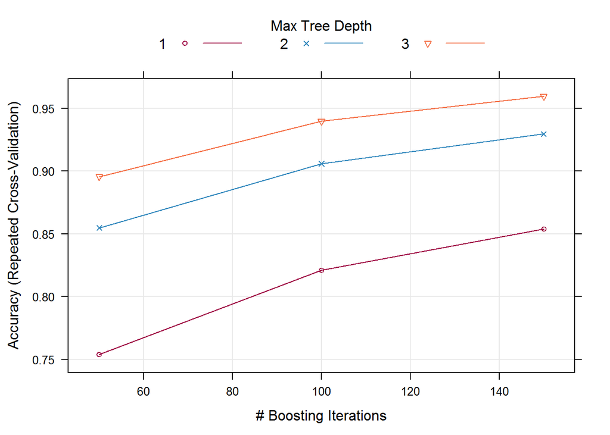

```r
trellis.par.set(caretTheme())
plot(gbmFit)
```

# Analysis on Validation Set

Here is my analysis of correct results on validation set. This is a good test to see out of sample error. With repeated cross validation, part of the training set is used as the test set, but this will be a larger sample.

```r
predictions_for_validation <- predict(gbmFit, newdata = validation_data,type = "raw")
confusionMatrix(validation_data$classe,predictions_for_validation)
```

```
## Confusion Matrix and Statistics
##
##           Reference
## Prediction    A    B    C    D    E
##          A 2198   24    5    5    0
##          B   48 1405   61    1    3
##          C    0   36 1309   19    4
##          D    4    5   52 1216    9
##          E    4   25    6   25 1382
##
## Overall Statistics
##
##                Accuracy : 0.9572
##                  95% CI : (0.9525, 0.9615)
##     No Information Rate : 0.2873
##     P-Value [Acc > NIR] : < 2.2e-16
##
##                   Kappa : 0.9458
##  Mcnemar's Test P-Value : 1.853e-10
##
## Statistics by Class:
##
##                      Class: A Class: B Class: C Class: D Class: E
## Sensitivity            0.9752   0.9398   0.9135   0.9605   0.9886
## Specificity            0.9939   0.9822   0.9908   0.9894   0.9907
## Pos Pred Value         0.9848   0.9256   0.9569   0.9456   0.9584
## Neg Pred Value         0.9900   0.9858   0.9809   0.9924   0.9975
## Prevalence             0.2873   0.1905   0.1826   0.1614   0.1782
## Detection Rate         0.2801   0.1791   0.1668   0.1550   0.1761
## Detection Prevalence   0.2845   0.1935   0.1744   0.1639   0.1838
## Balanced Accuracy      0.9845   0.9610   0.9521   0.9749   0.9896
```

As you can see our overall accuracy is 95%. This is slightly worse than we expected with an out of sample error as 5% This could be for a variety of reasons, and it may make sense to do this experiment with more algorithms and more tuning. In addition, note how the accuracy is not consistent for each class. It seems that class A and Class E may be more clear cut than predicting B, c and D, and further analysis is needed to understand this.